# Plate-boundary segments: structure feasibility, seismicity style and figure plan (v6.1)

Draft for the Science Advances re-framing (D-B107, PI 2026-11-26 16:05). Built Fri Nov 27 19:24:58 PST 2026; branch `analysis/plate-boundaries` at `0904802e` (worktree /home/mdenolle/wt_pbplan). Private working page; not peer reviewed. Catalog v6.1 (registered; D-B103, D-B104, D-B105, D-B108): these are the paper numbers (D-B111). Its clustering, Mc maps and fault surfaces are the v6.1 production products; the v6.0 feasibility study is kept at /wd1/mdenolle_data/paper_plan/plate_boundaries_plan.html.

**What this page answers.** D-B107 asks for a paper on fault-zone structure and seismicity style at the plate boundaries, with velocity structure shown only near faults and only where the model resolves it. Before figures are drawn: which boundaries does model v0.4.2 resolve, how large is the ensemble uncertainty there, how large are the structure contrasts against it, and how do the boundaries differ in seismicity style? Section 5 is the figure plan; draft mock-ups are in sections 4 and 6.

## 2. Segment rule and segment table

Rule (code `workflow/11_paper_plan/pb_common.py`, first match wins):

1. Located events of catalog v6.1 (any tier), first match wins; distances are horizontal.
2. Traces: plate boundaries v2 adopted (D-B117, pbv2_adopt.py): straight Gorda Ridge, Mendocino and Blanco segments with their step-overs from the relocated seismicity and the bathymetry (D-B116), JdF ridge Cleft-Endeavour on its bathymetric axis, PB2002 north of 48.4 N; subduction trace and triple junction PB2002.
3. AX: catalog region Axial. BL: catalog region Blanco. EN: catalog region Endeavour.
4. MTJ: within 40 km of the triple junction (PB2002: southern end of the JF\NA subduction trace).
5. MFZ: within 15 km of the PA-JF transform trace, south of 41 N.
6. Ridges: within 15 km of a PA-JF spreading axis: GR south of 43 N, JR 43-48.35 N, EXR north of 48.35 N.
7. Explorer region, rest: SOV within 15 km of a transform step, else EXP.
8. West of the PB2002 subduction trace (oceanic plate): GP south of 43 N, JP north of it.
9. South of the triple junction latitude (outside MTJ and MFZ): NAPA.
10. East of the trace, by depth relative to Slab2 (rel = depth - slab): Cascades region: MSH within 25 km of the summit, else CAS. Puget/Georgia and Other onshore: crust (PU, OC) if rel < -10 km or no Slab2. Every other event east of the trace: GS south of 41.5 N; north of it IS if rel >= +5 km, SIF if |rel| < 5 km, FA otherwise (also without Slab2).

Events: located earthquakes of v6.1 (event_flag empty: 3,433 flagged events left out, of them 105 analog_test_signal), tiers A-C, review P1 (Mount St Helens weekly-signal candidates, 116 further tier A-C events) left out. Fault surfaces v1 belong to the segment of most of their fit members at the v6.1 positions (table `surface_segments.csv`; 124 of 159 surfaces have ≥ 80 % of their members in one segment). Threshold sensitivity is in section 7.

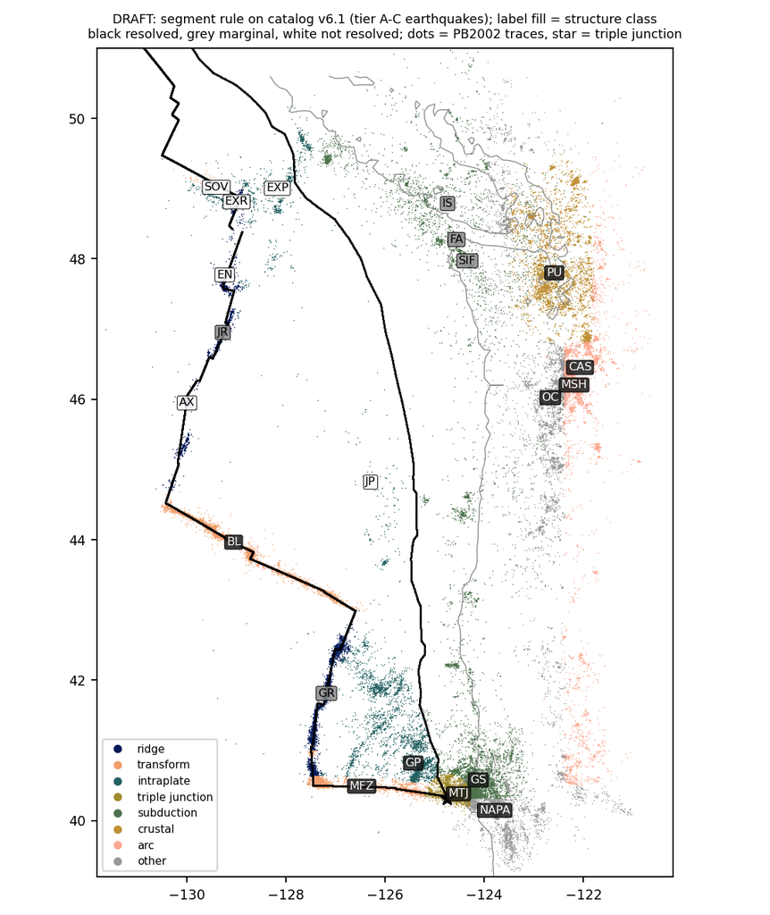

Segments on catalog v6.1 (tier A-C earthquakes, coloured by type) with the structure class of each segment (label fill: black resolved, grey marginal, white not resolved). Coastline: zero contour of the model surface. Draft.

Segment table. Structure class: section 3. Depth class from the depth-good events: good (median σz ≤ 3 km), fair (3-6 km), none (fewer than 50 depth-good events). Shares are of the events above the clustering Mc (v6.1 nearest- neighbour run). Migrating swarms: zbz swarm families ≥ 10 events + DBSCAN swarm-like clusters flagged migrating.

| seg | segment | type | events A-C | depth | structure | P / PS nodes ≤10 km | PS depth span (km) | checkerboard share P | Mc | b [95 % CI] | background % | MA % | swarm % | depth below surface p50 / p90 (km) | below 7.5 km/s | surfaces (dip) | migrating swarms | burstiness |
| --- | --- | --- | --- | --- | --- | --- | --- | --- | --- | --- | --- | --- | --- | --- | --- | --- | --- | --- |
| AX | Axial Seamount (JdF ridge) | ridge | 21,171 | good | not resolved | 0 / 0 | – | – | 0.35 | 0.80 [0.74, 0.82] | 50 | 14 | 29 | 1.8 / 2.5 | – | 0 | 3 + 0 | 0.88 |
| JR | JdF ridge, other segments | ridge | 1,492 | none | marginal | 13 / 0 | – | 0.00 | 1.95 | 1.41 [1.23, 1.58] | 55 | 9 | 18 | – | – | 3 (58°) | 0 + 0 | 0.62 |
| EN | Endeavour segment | ridge | 81 | none | not resolved | 0 / 0 | – | – | 1.65 | 0.70 | – | – | – | – | – | 0 | 0 + 0 | 0.44 |
| EXR | Explorer ridge | ridge | 198 | none | not resolved | 0 / 0 | – | – | 2.25 | 0.98 [0.73, 1.38] | 64 | 20 | 8 | – | – | 1 (86°) | 0 + 0 | 0.29 |
| GR | Gorda ridge | ridge | 3,860 | fair | marginal | 153 / 0 | – | 0.00 | 2.05 | 1.41 [1.27, 1.53] | 45 | 22 | 20 | 10.9 / 21.1 | – | 13 (69°) | 2 + 0 | 0.60 |
| BL | Blanco transform | transform | 36,523 | fair | resolved | 930 / 325 | 9-29 | 0.28 | 1.75 | 1.19 [1.15, 1.22] | 48 | 18 | 25 | 5.5 / 17.6 | 0.36 | 30 (87°) | 3 + 9 | 0.67 |
| MFZ | Mendocino fault zone | transform | 3,253 | fair | resolved | 236 / 66 | 21-34 | 0.00 | 1.95 | 1.00 [0.92, 1.07] | 72 | 23 | 1 | 25.2 / 34.5 | 0.75 | 8 (67°) | 0 + 0 | 0.61 |
| SOV | Sovanco transform | transform | 86 | none | not resolved | 0 / 0 | – | – | 2.35 | – | 89 | 9 | 0 | – | – | 0 | 0 + 0 | – |
| JP | JdF plate interior | intraplate | 316 | poor | not resolved | 0 / 0 | – | – | 1.95 | 0.98 [0.78, 1.23] | 56 | 39 | 0 | 28.0 / 41.6 | – | 1 (86°) | 0 + 0 | 0.25 |
| GP | Gorda plate interior | intraplate | 4,710 | fair | resolved | 230 / 80 | 21-34 | 0.13 | 1.95 | 1.17 [0.99, 1.26] | 32 | 66 | 1 | 17.8 / 25.4 | 0.52 | 7 (78°) | 0 + 0 | 0.40 |
| EXP | Explorer plate / Nootka | intraplate | 873 | none | not resolved | 0 / 0 | – | – | 2.05 | 0.88 [0.75, 0.98] | 38 | 57 | 1 | – | – | 5 (68°) | 0 + 0 | 0.50 |
| MTJ | Mendocino triple junction | triple junction | 10,474 | good | resolved | 366 / 200 | 9-34 | 0.06 | 1.35 | 0.92 [0.87, 0.95] | 64 | 31 | 1 | 24.0 / 30.8 | 0.54 | 6 (49°) | 0 + 0 | 0.13 |
| GS | Gorda slab beneath the margin (S of 41.5 N) | subduction | 11,946 | good | resolved | 632 / 147 | 9-29 | 0.08 | 1.35 | 1.09 [1.05, 1.12] | 68 | 23 | 3 | 21.8 / 30.5 | 0.23 | 7 (55°) | 0 + 1 | 0.21 |
| FA | Forearc upper plate (N of 41.5 N) | subduction | 1,882 | fair | marginal | 232 / 1 | – | 0.00 | 1.45 | 1.33 [1.16, 1.49] | 68 | 16 | 5 | 10.9 / 20.5 | 0.00 | 10 (51°) | 0 + 0 | 0.22 |
| SIF | Interface zone (N of 41.5 N) | subduction | 1,307 | good | marginal | 155 / 0 | – | 0.00 | 1.45 | 1.08 [0.99, 1.19] | 89 | 7 | 2 | 27.2 / 47.4 | 0.22 | 2 (78°) | 0 + 0 | 0.10 |
| IS | JdF intraslab (N of 41.5 N) | subduction | 1,150 | fair | marginal | 75 / 0 | – | 0.00 | 1.65 | 0.74 [0.69, 0.81] | 65 | 30 | 3 | 37.8 / 61.0 | 1.00 | 3 (65°) | 0 + 0 | 0.15 |
| PU | Puget-Georgia crust | crustal | 11,348 | good | resolved | 1321 / 205 | 9-25 | 0.13 | 1.25 | 1.45 [1.32, 1.51] | 74 | 15 | 5 | 15.7 / 23.1 | – | 22 (43°) | 0 + 0 | 0.06 |
| MSH | Mount St Helens | arc | 7,799 | good | resolved | 210 / 137 | 1-18 | 0.53 | 0.35 | 1.01 [0.93, 1.05] | 39 | 14 | 28 | 6.1 / 15.2 | – | 3 (43°) | 2 + 0 | 0.14 |
| CAS | Cascade arc, other | arc | 5,045 | good | resolved | 676 / 225 | 1-21 | 0.23 | 1.45 | 1.17 [1.06, 1.24] | 64 | 12 | 15 | 12.9 / 21.3 | – | 9 (44°) | 0 + 0 | 0.13 |
| OC | Other onshore crust | other | 7,498 | good | resolved | 1142 / 226 | 1-21 | 0.21 | 1.05 | 1.11 [1.08, 1.29] | 82 | 11 | 1 | 15.0 / 22.4 | 0.00 | 21 (55°) | 0 + 0 | 0.08 |
| NAPA | North America-Pacific, south of the MTJ | other | 4,305 | good | resolved | 235 / 78 | 9-29 | 0.00 | 1.35 | 0.88 [0.83, 0.93] | 75 | 15 | 2 | 23.2 / 32.3 | 0.27 | 8 (55°) | 0 + 0 | 0.24 |

### Plate boundaries v2 (D-B116 rules, adopted D-B117)

The segment rule uses the adopted plate boundaries v2 (pbv2_adopt.py, data/paper_plan/plate_boundaries_v2/plate_axes_v2_adopted.csv; rules pre-registered in RULES.md). Straight segments chosen by BIC are fitted to axis picks of the relocated seismicity (v6.1 tier A-B, horizontal error ≤ 3 km) and compared with the bathymetric axes. Mendocino transform: 8.6 km north of PB2002 (95 %: 8.0-8.8), at the base of the north-facing slope of the Mendocino Ridge (seismicity minus bathymetric pick -0.5 km); it joins the PB2002 triple junction, which is kept, by a 8.4 km connector (A7). Blanco transform: three segments with two step-overs, 12.4 km at 128.69 W and 3.1 km at 129.16 W. Gorda Ridge on its axial valley, stepping east by 2.6 km at 41.05 N, 10.6 km at 41.66 N, 8.4 km at 42.44 N. Juan de Fuca Ridge on its bathymetric axis (axial high, Axial to Northern Symmetric), Endeavour from the MAPRIDGES v2602 trace (A6). Explorer, Sovanco and Nootka keep PB2002. Buffer 15 km and every other rule unchanged; events are never moved. Against the previous axes (gmrt: D-B113 axes v1), 727 tier A-C earthquakes change segment.

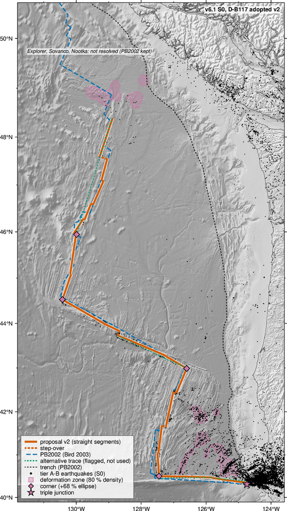

Plate boundaries v2 (report: /wd1/mdenolle_data/paper_plan/plate_boundaries_v2/report_boundaries.html).

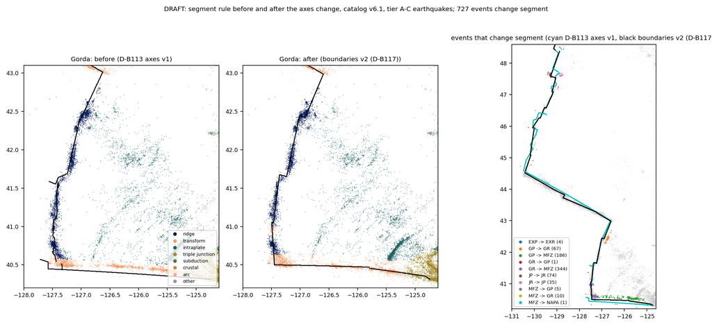

Segments with the previous axes (gmrt) and with boundaries v2, and the events that change segment.

Events per segment before and after:

| seg | before | after | moved_out | moved_in | out_to | in_from |
| --- | --- | --- | --- | --- | --- | --- |
| JR | 1,453 | 1,492 | 35 | 74 | JP:35 | JP:74 |
| EXR | 194 | 198 | 0 | 4 | – | EXP:4 |
| GR | 4,128 | 3,860 | 345 | 77 | MFZ:344;GP:1 | GP:67;MFZ:10 |
| MFZ | 2,739 | 3,253 | 16 | 530 | GR:10;GP:5;NAPA:1 | GR:344;GP:186 |
| JP | 355 | 316 | 74 | 35 | JR:74 | JR:35 |
| GP | 4,957 | 4,710 | 253 | 6 | MFZ:186;GR:67 | MFZ:5;GR:1 |
| EXP | 877 | 873 | 4 | 0 | EXR:4 | – |
| NAPA | 4,304 | 4,305 | 0 | 1 | – | MFZ:1 |

Changed metrics of the affected segments (before → after):

| metric | EXP | EXR | GP | GR | JP | JR | MFZ | NAPA |
| --- | --- | --- | --- | --- | --- | --- | --- | --- |
| n_events | 877 → 873 | 194 → 198 | 4,957 → 4,710 | 4,128 → 3,860 | 355 → 316 | 1,453 → 1,492 | 2,739 → 3,253 | 4,304 → 4,305 |
| b | 0.88 → 0.88 | 1.01 → 0.98 | 1.18 → 1.17 | 1.41 → 1.41 | 1.08 → 0.98 | 1.29 → 1.41 | 0.97 → 1.00 | 0.88 → 0.88 |
| pct_bg | 38.27 → 38.11 | 63.33 → 63.93 | 33.22 → 32.32 | 45.08 → 44.51 | 58.54 → 55.88 | 53.55 → 54.72 | 72.43 → 71.57 | 74.95 → 74.95 |
| pct_MA | 57.14 → 57.29 | 20 → 19.67 | 64.71 → 65.60 | 20.93 → 21.79 | 34.76 → 39.41 | 11.48 → 8.89 | 23.18 → 23.19 | 14.71 → 14.71 |
| pct_swarm | 1.28 → 1.28 | 8.33 → 8.20 | 0.65 → 0.67 | 19.50 → 20.30 | 1.83 → 0 | 17.21 → 18.33 | 1.24 → 1.12 | 2.29 → 2.29 |
| bsf_med | – → – | – → – | 17.83 → 17.79 | 10.86 → 10.93 | 27.99 → 27.99 | – → – | 25.36 → 25.23 | 23.23 → 23.23 |
| bsf_p90 | – → – | – → – | 27.18 → 25.43 | 21.60 → 21.06 | 41.65 → 41.65 | – → – | 34.39 → 34.45 | 32.32 → 32.33 |
| frac_below_z75 | – → – | – → – | 0.63 → 0.52 | – → – | – → – | – → – | 0.75 → 0.75 | 0.27 → 0.27 |
| n_surfaces | 5 → 5 | 1 → 1 | 8 → 7 | 13 → 13 | 1 → 1 | 3 → 3 | 7 → 8 | 8 → 8 |
| dip_wmed | 67.96 → 67.96 | 85.90 → 85.90 | 76.81 → 77.80 | 68.71 → 69.19 | 86.50 → 86.50 | 58.07 → 58.07 | 68.39 → 67 | 54.69 → 54.69 |
| burst_all | 0.50 → 0.50 | 0.37 → 0.29 | 0.41 → 0.40 | 0.60 → 0.60 | 0.23 → 0.25 | 0.63 → 0.62 | 0.56 → 0.61 | 0.24 → 0.24 |
| nP_10 | 0 → 0 | 0 → 0 | 277 → 230 | 163 → 153 | 0 → 0 | 13 → 13 | 200 → 236 | 235 → 235 |
| nPS_10 | 0 → 0 | 0 → 0 | 94 → 80 | 1 → 0 | 0 → 0 | 0 → 0 | 58 → 66 | 78 → 78 |
| class | not resolved → not resolved | not resolved → not resolved | resolved → resolved | marginal → marginal | not resolved → not resolved | marginal → marginal | resolved → resolved | resolved → resolved |

Contrasts whose value or verdict changed (D-B111 rule):

| seg | var | contrast | D_real_before | sigma_ens_before | S95_before | survives_before | D_real_after | sigma_ens_after | S95_after | survives_after |
| --- | --- | --- | --- | --- | --- | --- | --- | --- | --- | --- |
| JR | Vp | across | +0.055 | 0.18 | 0.35 | 0 | +0.082 | 0.17 | 0.33 | 0 |
| GR | Vp | near-far | -0.221 | 0.05 | 0.15 | 1 | -0.210 | 0.05 | 0.12 | 1 |
| GR | Vp | across | -0.183 | 0.08 | 0.15 | 1 | -0.158 | 0.08 | 0.15 | 0 |
| GR | Vp | along | -0.307 | 0.14 | 0.26 | 1 | -0.265 | 0.14 | 0.27 | 0 |
| MFZ | Vp | near-far | -0.101 | 0.04 | 0.06 | 1 | -0.128 | 0.04 | 0.07 | 1 |
| MFZ | Vp | across | -0.021 | 0.05 | 0.06 | 0 | -0.019 | 0.06 | 0.07 | 0 |
| MFZ | Vp | along | +0.036 | 0.10 | 0.17 | 0 | +0.102 | 0.09 | 0.16 | 0 |
| MFZ | Vs | near-far | -0.114 | 0.03 | 0.05 | 1 | -0.128 | 0.03 | 0.05 | 1 |
| MFZ | Vs | across | +0.040 | 0.04 | 0.07 | 0 | +0.059 | 0.06 | 0.08 | 0 |
| MFZ | Vs | along | +0.072 | 0.07 | 0.10 | 0 | +0.062 | 0.07 | 0.10 | 0 |
| MFZ | VpVs | near-far | -0.006 | 0.01 | 0.02 | 0 | -0.010 | 0.01 | 0.02 | 0 |
| MFZ | VpVs | across | -0.005 | 0.01 | 0.04 | 0 | +0.009 | 0.02 | 0.05 | 0 |
| MFZ | VpVs | along | +0.014 | 0.02 | 0.03 | 0 | +0.009 | 0.02 | 0.03 | 0 |
| GP | Vp | near-far | +0.145 | 0.04 | 0.07 | 1 | +0.149 | 0.04 | 0.06 | 1 |
| GP | Vp | across | +0.005 | 0.05 | 0.05 | 0 | -0.013 | 0.05 | 0.06 | 0 |
| GP | Vp | along | -0.057 | 0.06 | 0.09 | 0 | +0.001 | 0.07 | 0.09 | 0 |
| GP | Vs | near-far | +0.027 | 0.03 | 0.09 | 0 | +0.048 | 0.03 | 0.10 | 0 |
| GP | Vs | across | +0.095 | 0.03 | 0.07 | 1 | +0.070 | 0.04 | 0.09 | 0 |
| GP | Vs | along | -0.047 | 0.05 | 0.09 | 0 | -0.052 | 0.04 | 0.10 | 0 |
| GP | VpVs | near-far | +0.014 | 0.01 | 0.03 | 0 | +0.012 | 0.01 | 0.04 | 0 |
| GP | VpVs | across | -0.012 | 0.01 | 0.02 | 0 | -0.018 | 0.01 | 0.03 | 0 |
| GP | VpVs | along | +0.012 | 0.01 | 0.03 | 0 | +0.015 | 0.01 | 0.03 | 0 |
| NAPA | Vp | near-far | -0.029 | 0.05 | 0.07 | 0 | -0.036 | 0.05 | 0.07 | 0 |
| NAPA | Vp | across | -0.306 | 0.06 | 0.09 | 1 | -0.293 | 0.06 | 0.09 | 1 |

Headline metrics (b, Mc, swarm share, 90th percentile of the depth below the surface) whose new value lies outside the previous 95 % bootstrap interval: GP bsf_p90 27.18 → 25.43 (previous 95 %: 25.75-29.20).

## 3. Structure feasibility

Model v0.4.2 on its node grid (0.125° x 0.1°, about 10 x 11 km; depth nodes 2-6 km apart above 30 km). Masks as used so far: rock and (checkerboard-resolved or DWS ≥ 100), P for Vp, S for Vs, both for Vp/Vs; nodes whose Vs was reverted to the reference (D-B051) are left out of the S mask. Distance of a node: 3-D distance to the nearest point of the segment's fault surfaces (1 km mesh) or of its seismicity (depth-good events where there are ≥ 50, else tier A-C). Ensemble 1σ: v0.4.2+ens.100 Vp_std (x 1.50) and Vs_std (x 1.35) as stored; Vp/Vs: the raw member std (factor 1.0, D-B111). Class: **resolved** ≥ 15 P and ≥ 10 P-and-S nodes within 10 km over ≥ 3 depth layers; **marginal** ≥ 5 P nodes within 10 km; else **not resolved**. Spans list depth layers with ≥ 3 nodes.

| seg | type | surfaces | reference events | nP_5 | nP_10 | nP_20 | nS_10 | nPS_5 | nPS_10 | nPS_20 | P span (km) | PS span (km) | cb share P | cb share S | cb cell (km) | 1σ Vp | 1σ Vs | 1σ Vp/Vs | events on P nodes | events on PS nodes | max \|Δ\|/σ | class |
| --- | --- | --- | --- | --- | --- | --- | --- | --- | --- | --- | --- | --- | --- | --- | --- | --- | --- | --- | --- | --- | --- | --- |
| AX | ridge | 0 | depth-good | 0 | 0 | 0 | 0 | 0 | 0 | 0 | – | – | – | – | – | – | – | – | 0.00 | 0.00 | – | not resolved |
| JR | ridge | 3 | tier A-C | 7 | 13 | 28 | 0 | 0 | 0 | 0 | 5-7 | – | 0.00 | – | – | 0.243 | – | – | 0.03 | 0.00 | 0.7 | marginal |
| EN | ridge | 0 | tier A-C | 0 | 0 | 0 | 0 | 0 | 0 | 0 | – | – | – | – | – | – | – | – | 0.00 | 0.00 | – | not resolved |
| EXR | ridge | 1 | tier A-C | 0 | 0 | 0 | 0 | 0 | 0 | 0 | – | – | – | – | – | – | – | – | 0.00 | 0.00 | – | not resolved |
| GR | ridge | 13 | depth-good | 104 | 153 | 220 | 0 | 0 | 0 | 1 | 9-40 | – | 0.00 | – | – | 0.201 | – | – | 0.50 | 0.00 | 4.2 | marginal |
| BL | transform | 30 | depth-good | 632 | 930 | 1,128 | 331 | 234 | 325 | 376 | 3-40 | 9-29 | 0.28 | 0.66 | 40 | 0.281 | 0.159 | 0.055 | 0.77 | 0.28 | 1.7 | resolved |
| MFZ | transform | 8 | depth-good | 143 | 236 | 341 | 66 | 49 | 66 | 94 | 15-40 | 21-34 | 0.00 | 0.00 | 40 | 0.205 | 0.095 | 0.032 | 0.82 | 0.34 | 4.2 | resolved |
| SOV | transform | 0 | tier A-C | 0 | 0 | 0 | 0 | 0 | 0 | 0 | – | – | – | – | – | – | – | – | 0.00 | 0.00 | – | not resolved |
| JP | intraplate | 1 | depth-good | 0 | 0 | 0 | 0 | 0 | 0 | 0 | – | – | – | – | – | – | – | – | 0.00 | 0.00 | – | not resolved |
| GP | intraplate | 7 | depth-good | 104 | 230 | 441 | 80 | 35 | 80 | 129 | 15-34 | 21-34 | 0.13 | 0.00 | 40 | 0.180 | 0.083 | 0.027 | 0.62 | 0.47 | 3.7 | resolved |
| EXP | intraplate | 5 | tier A-C | 0 | 0 | 0 | 0 | 0 | 0 | 0 | – | – | – | – | – | – | – | – | 0.00 | 0.00 | – | not resolved |
| MTJ | triple junction | 6 | depth-good | 285 | 366 | 496 | 200 | 164 | 200 | 262 | 1-40 | 9-34 | 0.06 | 0.00 | 40 | 0.173 | 0.088 | 0.031 | 0.95 | 0.82 | 7.2 | resolved |
| GS | subduction | 7 | depth-good | 494 | 632 | 823 | 147 | 117 | 147 | 212 | 1-40 | 9-29 | 0.08 | 0.00 | 40 | 0.173 | 0.091 | 0.030 | 0.89 | 0.61 | 10.9 | resolved |
| FA | subduction | 10 | depth-good | 106 | 232 | 585 | 1 | 0 | 1 | 30 | 1-34 | – | 0.00 | 0.00 | – | 0.195 | 0.115 | 0.040 | 0.26 | 0.00 | 2.6 | marginal |
| SIF | subduction | 2 | depth-good | 89 | 155 | 397 | 0 | 0 | 0 | 8 | 12-47 | – | 0.00 | – | – | 0.221 | – | – | 0.23 | 0.00 | 1.1 | marginal |
| IS | subduction | 3 | depth-good | 19 | 75 | 167 | 0 | 0 | 0 | 0 | 18-65 | – | 0.00 | – | – | 0.222 | – | – | 0.11 | 0.00 | 2.4 | marginal |
| PU | crustal | 22 | depth-good | 1,079 | 1,321 | 1,449 | 205 | 170 | 205 | 229 | 1-34 | 9-25 | 0.13 | 0.00 | 40 | 0.126 | 0.089 | 0.030 | 0.75 | 0.34 | 4.6 | resolved |
| MSH | arc | 3 | depth-good | 149 | 210 | 343 | 137 | 104 | 137 | 185 | -1-21 | 1-18 | 0.53 | 0.00 | 40 | 0.090 | 0.048 | 0.020 | 0.98 | 0.85 | 2.3 | resolved |
| CAS | arc | 9 | depth-good | 383 | 676 | 1,104 | 225 | 145 | 225 | 336 | 1-25 | 1-21 | 0.23 | 0.00 | 40 | 0.132 | 0.058 | 0.022 | 0.54 | 0.34 | 3.3 | resolved |
| OC | other | 21 | depth-good | 687 | 1,142 | 1,650 | 226 | 177 | 226 | 322 | 1-29 | 1-21 | 0.21 | 0.00 | 40 | 0.140 | 0.059 | 0.022 | 0.64 | 0.34 | 7.2 | resolved |
| NAPA | other | 8 | depth-good | 169 | 235 | 366 | 78 | 68 | 78 | 125 | 1-40 | 9-29 | 0.00 | 0.00 | – | 0.170 | 0.094 | 0.032 | 0.69 | 0.45 | 5.4 | resolved |

### Contrasts against the ensemble

Depth-matched contrasts (per depth layer, weighted by the smaller node count): *near-far* = nodes within 5 km minus nodes 10-20 km away; *across* = the two sides of the segment's strike line (PCA of its epicentres; nodes within 3 km of the line left out; + = left of the strike direction); *along* = the third of the nodes within 10 km at the strike-azimuth end (strike 0-180°, `segment_axes.csv`) minus the third at the other end. σ of Δ: the same contrast in each of the 100 members, std x calibration factor. "members same sign" = share of members whose contrast has the sign of the v0.4.2 value.

| seg | var | contrast | n1 | n2 | Δ (v0.4.2) | σ of Δ (members) | \|Δ\|/σ | members same sign | node 1σ | \|Δ\|/node 1σ |
| --- | --- | --- | --- | --- | --- | --- | --- | --- | --- | --- |
| JR | Vp | across | 19 | 4 | +0.082 | 0.170 | 0.5 | 0.73 | 0.240 | 0.34 |
| JR | Vp | along | 5 | 5 | +0.136 | 0.188 | 0.7 | 0.86 | 0.243 | 0.56 |
| JR | Vp | near-far | 7 | 15 | +0.101 | 0.183 | 0.5 | 0.79 | 0.238 | 0.42 |
| GR | Vp | across | 76 | 111 | -0.158 | 0.083 | 1.9 | 1.00 | 0.209 | 0.76 |
| GR | Vp | along | 54 | 54 | -0.265 | 0.140 | 1.9 | 0.99 | 0.214 | 1.24 |
| GR | Vp | near-far | 104 | 67 | -0.210 | 0.050 | 4.2 | 1.00 | 0.204 | 1.03 |
| BL | Vp | across | 456 | 543 | -0.078 | 0.047 | 1.7 | 0.98 | 0.288 | 0.27 |
| BL | Vp | along | 315 | 313 | -0.127 | 0.078 | 1.6 | 1.00 | 0.294 | 0.43 |
| BL | Vp | near-far | 632 | 198 | -0.037 | 0.046 | 0.8 | 0.86 | 0.280 | 0.13 |
| BL | VpVs | across | 123 | 199 | -0.002 | 0.008 | 0.3 | 0.38 | 0.057 | 0.04 |
| BL | VpVs | along | 110 | 113 | -0.015 | 0.013 | 1.1 | 0.95 | 0.058 | 0.26 |
| BL | VpVs | near-far | 234 | 51 | +0.019 | 0.012 | 1.6 | 0.87 | 0.055 | 0.34 |
| BL | Vs | across | 136 | 202 | -0.036 | 0.025 | 1.4 | 1.00 | 0.162 | 0.22 |
| BL | Vs | along | 111 | 116 | +0.013 | 0.038 | 0.3 | 0.78 | 0.162 | 0.08 |
| BL | Vs | near-far | 235 | 61 | -0.028 | 0.029 | 0.9 | 0.88 | 0.159 | 0.17 |
| MFZ | Vp | across | 230 | 65 | -0.019 | 0.056 | 0.3 | 0.67 | 0.196 | 0.10 |
| MFZ | Vp | along | 82 | 79 | +0.102 | 0.095 | 1.1 | 0.99 | 0.208 | 0.49 |
| MFZ | Vp | near-far | 143 | 105 | -0.128 | 0.039 | 3.3 | 1.00 | 0.195 | 0.66 |
| MFZ | VpVs | across | 69 | 5 | +0.009 | 0.018 | 0.5 | 0.65 | 0.031 | 0.28 |
| MFZ | VpVs | along | 22 | 23 | +0.009 | 0.018 | 0.5 | 0.55 | 0.032 | 0.30 |
| MFZ | VpVs | near-far | 49 | 28 | -0.010 | 0.010 | 1.0 | 0.74 | 0.031 | 0.33 |
| MFZ | Vs | across | 69 | 5 | +0.059 | 0.056 | 1.1 | 0.93 | 0.091 | 0.65 |
| MFZ | Vs | along | 22 | 23 | +0.062 | 0.074 | 0.8 | 0.89 | 0.100 | 0.62 |
| MFZ | Vs | near-far | 49 | 28 | -0.128 | 0.030 | 4.2 | 1.00 | 0.090 | 1.41 |
| GP | Vp | across | 143 | 268 | -0.013 | 0.052 | 0.3 | 0.54 | 0.185 | 0.07 |
| GP | Vp | along | 80 | 78 | +0.001 | 0.070 | 0.0 | 0.76 | 0.189 | 0.01 |
| GP | Vp | near-far | 104 | 211 | +0.149 | 0.040 | 3.7 | 1.00 | 0.187 | 0.80 |
| GP | VpVs | across | 78 | 39 | -0.018 | 0.010 | 1.8 | 0.98 | 0.028 | 0.64 |
| GP | VpVs | along | 28 | 28 | +0.015 | 0.013 | 1.1 | 0.75 | 0.027 | 0.56 |
| GP | VpVs | near-far | 35 | 49 | +0.012 | 0.009 | 1.4 | 0.94 | 0.029 | 0.41 |

[output cut: 75 more lines]

### Circularity control (synthetic ensemble, D-B111)

**Rule, pre-registered** in `data/paper_plan/plate_boundaries/RESUME.md` at Fri Nov 27 09:38:33 PST 2026 (commit 6b64abf1, pushed before any synthetic contrast was computed): a contrast counts only if |Δ_real| ≥ 2σ_ens (Vp x1.50, Vs x1.35, Vp/Vs x1.00) and |Δ_real| ≥ S95, where S95 is the 95th percentile of |Δ_rec,i − Δ_truth| over the synthetic members; fewer than 50 members with a value means not testable.

Synthetic set: `/wd1/mdenolle_data/tomo_v1/ensemble_v0.4.2/synth`, one truth (v0.4.2 tomography x (1 + f), 3 % random field, 30 km / 8 km correlation, truth hypocentres drawn about v4-NLL3D), synthetic data on the real event-station geometry and pick list, 100 members s000-s099 inverted from their own start draws, and five noise-floor clones of s000. The same node sets and depth matching as the real contrasts; truth and members compared before the D-B073 node rule. Spurious contrast = recovered − truth: it holds what ray sampling, the events' trade-offs and the regularisation do to a contrast that is in the truth. All 105 contrasts were testable.

**Null truth (D-B112).** Rule pre-registered in RESUME.md at Fri Nov 27 10:13:48 PST 2026 (commit 6d45ad98), before the null truth was built: a contrast is claimed only if it passes the D-B111 rule and |Δ_real| ≥ N95, the 95th percentile of |Δ_rec,i − Δ_truth| over the null members (≥ 15 members). Null truth: the calibration truth (v0.4.2 x (1 + f), same random field, hypocentres and noise draws) with every rock node within 45 km of a segment's faults or seismicity set to its depth-layer mean in that segment's zone (109,661 nodes; JR 6,704, GR 1,780, BL 9,429, MFZ 2,027, GP 8,446, MTJ 986, GS 2,749, FA 9,802, SIF 7,656, IS 15,439, PU 4,792, MSH 358, CAS 17,908, OC 14,978, NAPA 6,607; median change of Vp 0.23 km/s, p95 0.85). Synthetic data from the frozen tomoDD-SE_syn binaries; 20 members (s000-s019, the same seeds as the calibration members) through M0, four tiles and the merge in /wd1/mdenolle_data/tomo_v1/ensemble_v0.4.2_null. The truth contrast is zero where both node sets lie in one zone. N95 is a median 1.02 of S95.

**Null zones and the current axes.** The null truth's flattened zones were built on the PB2002 segments (null_zones.npz, reconstructed exactly); the members are scored on the current node sets. Zones are nearest-segment regions, so only about half of a contrast's nodes lie in its own zone (median 0.53 with the PB2002 node sets, 0.51 with the current ones) and the null truth keeps zone-boundary contrasts (median |Δ truth| 0.034 / 0.037 km/s or Vp/Vs units); 6 of 105 current contrasts lie inside one zone (true no-contrast tests). The rule (recovered − truth) still measures the recovery error of a known truth. Contrasts whose null-truth value moved by more than 0.05 with the axis change, or whose own-zone share fell by more than 0.15: GR: Vp across (Δ truth -0.03 → -0.11, own-zone share 0.59 → 0.49), Vp along (Δ truth -0.07 → -0.29, own-zone share 0.71 → 0.59); MFZ: VpVs across (Δ truth +0.01 → +0.01, own-zone share 0.50 → 0.31), Vs across (Δ truth +0.00 → +0.00, own-zone share 0.50 → 0.31).

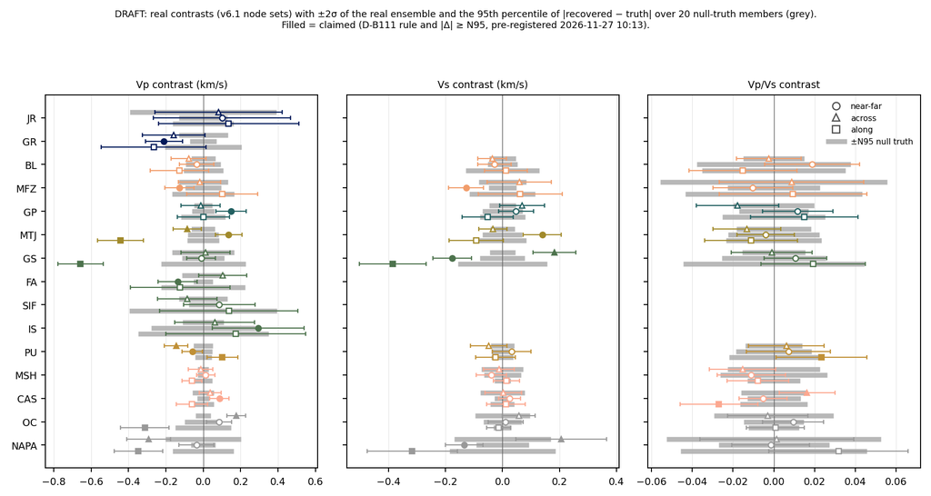

Real contrasts with ±2σ of the real ensemble and ±N95 of the null-truth members (grey). Filled = claimed. Draft.

Against the same 20 members scored on the previous axes (gmrt): 31 claimed there; gained here: none; lost here: GP Vs across; GR Vp across; GR Vp along.

| seg | var | contrast | Δ real | σ ens | S95 | Δ null truth | null spurious mean | null spurious sd | N95 = p95 \|rec − truth\| | p95 \|rec\| (variant) | cal − null (paired members) | cal − null (truths) | members | D-B111 | ≥ N95 | verdict |
| --- | --- | --- | --- | --- | --- | --- | --- | --- | --- | --- | --- | --- | --- | --- | --- | --- |
| JR | Vp | near-far | +0.101 | 0.183 | 0.272 | +0.023 | +0.043 | 0.069 | 0.130 | 0.153 | +0.003 | -0.043 | 20 | 0 | 0 | – |
| JR | Vp | across | +0.082 | 0.170 | 0.333 | +0.050 | -0.014 | 0.186 | 0.391 | 0.363 | +0.036 | +0.095 | 20 | 0 | 0 | – |
| JR | Vp | along | +0.136 | 0.188 | 0.201 | +0.079 | -0.002 | 0.101 | 0.164 | 0.199 | +0.014 | +0.027 | 20 | 0 | 0 | – |
| GR | Vp | near-far | -0.210 | 0.050 | 0.124 | -0.084 | -0.012 | 0.046 | 0.071 | 0.154 | -0.081 | -0.138 | 20 | 1 | 1 | claimed |
| GR | Vp | across | -0.158 | 0.083 | 0.150 | -0.105 | +0.046 | 0.067 | 0.131 | 0.152 | +0.071 | +0.071 | 20 | 0 | 1 | – |
| GR | Vp | along | -0.265 | 0.140 | 0.269 | -0.289 | -0.032 | 0.108 | 0.205 | 0.494 | +0.227 | +0.313 | 20 | 0 | 1 | – |
| BL | Vp | near-far | -0.037 | 0.046 | 0.098 | +0.001 | -0.039 | 0.032 | 0.093 | 0.093 | -0.010 | +0.003 | 20 | 0 | 0 | – |
| BL | Vp | across | -0.078 | 0.047 | 0.064 | +0.000 | -0.016 | 0.031 | 0.064 | 0.064 | -0.023 | -0.025 | 20 | 0 | 1 | – |
| BL | Vp | along | -0.127 | 0.078 | 0.109 | -0.000 | -0.026 | 0.049 | 0.106 | 0.107 | -0.237 | -0.318 | 20 | 0 | 1 | – |
| BL | Vs | near-far | -0.028 | 0.029 | 0.084 | +0.000 | +0.020 | 0.025 | 0.053 | 0.053 | -0.047 | -0.074 | 20 | 0 | 0 | – |
| BL | Vs | across | -0.036 | 0.025 | 0.028 | +0.000 | -0.019 | 0.017 | 0.047 | 0.047 | +0.006 | -0.008 | 20 | 0 | 0 | – |
| BL | Vs | along | +0.013 | 0.038 | 0.116 | +0.000 | -0.090 | 0.033 | 0.130 | 0.130 | +0.071 | +0.062 | 20 | 0 | 0 | – |
| BL | VpVs | near-far | +0.019 | 0.012 | 0.059 | +0.000 | -0.021 | 0.014 | 0.038 | 0.038 | +0.024 | +0.045 | 20 | 0 | 0 | – |
| BL | VpVs | across | -0.002 | 0.008 | 0.025 | -0.000 | +0.003 | 0.009 | 0.015 | 0.015 | -0.005 | +0.008 | 20 | 0 | 0 | – |
| BL | VpVs | along | -0.015 | 0.013 | 0.039 | -0.000 | +0.024 | 0.012 | 0.035 | 0.035 | -0.062 | -0.056 | 20 | 0 | 0 | – |
| MFZ | Vp | near-far | -0.128 | 0.039 | 0.068 | +0.015 | -0.046 | 0.033 | 0.096 | 0.081 | -0.024 | -0.090 | 20 | 1 | 1 | claimed |
| MFZ | Vp | across | -0.019 | 0.056 | 0.075 | -0.038 | +0.078 | 0.039 | 0.131 | 0.093 | -0.125 | -0.034 | 20 | 0 | 0 | – |
| MFZ | Vp | along | +0.102 | 0.095 | 0.164 | +0.048 | +0.057 | 0.072 | 0.166 | 0.214 | +0.073 | +0.172 | 20 | 0 | 0 | – |
| MFZ | Vs | near-far | -0.128 | 0.030 | 0.048 | -0.007 | +0.005 | 0.024 | 0.049 | 0.042 | -0.037 | -0.045 | 20 | 1 | 1 | claimed |
| MFZ | Vs | across | +0.059 | 0.056 | 0.079 | +0.001 | +0.019 | 0.049 | 0.083 | 0.082 | +0.001 | +0.011 | 20 | 0 | 0 | – |
| MFZ | Vs | along | +0.062 | 0.074 | 0.104 | +0.039 | +0.020 | 0.054 | 0.116 | 0.154 | -0.072 | -0.078 | 20 | 0 | 0 | – |
| MFZ | VpVs | near-far | -0.010 | 0.010 | 0.022 | -0.019 | -0.006 | 0.012 | 0.023 | 0.042 | +0.029 | +0.022 | 20 | 0 | 0 | – |
| MFZ | VpVs | across | +0.009 | 0.018 | 0.052 | +0.010 | +0.011 | 0.023 | 0.056 | 0.066 | -0.025 | +0.006 | 20 | 0 | 0 | – |
| MFZ | VpVs | along | +0.009 | 0.018 | 0.033 | +0.025 | +0.011 | 0.022 | 0.043 | 0.068 | -0.067 | -0.044 | 20 | 0 | 0 | – |
| GP | Vp | near-far | +0.149 | 0.040 | 0.064 | +0.038 | -0.014 | 0.028 | 0.061 | 0.064 | +0.123 | +0.133 | 20 | 1 | 1 | claimed |
| GP | Vp | across | -0.013 | 0.052 | 0.055 | -0.106 | +0.011 | 0.031 | 0.049 | 0.153 | -0.067 | -0.052 | 20 | 0 | 0 | – |
| GP | Vp | along | +0.001 | 0.070 | 0.093 | +0.032 | -0.056 | 0.044 | 0.119 | 0.086 | -0.061 | -0.142 | 20 | 0 | 0 | – |
| GP | Vs | near-far | +0.048 | 0.031 | 0.102 | +0.047 | -0.032 | 0.025 | 0.070 | 0.057 | +0.043 | +0.073 | 20 | 0 | 0 | – |
| GP | Vs | across | +0.070 | 0.039 | 0.086 | -0.049 | +0.008 | 0.032 | 0.047 | 0.085 | +0.041 | +0.031 | 20 | 0 | 1 | – |
| GP | Vs | along | -0.052 | 0.045 | 0.099 | +0.013 | +0.003 | 0.043 | 0.080 | 0.068 | -0.100 | -0.147 | 20 | 0 | 0 | – |

[output cut: 75 more lines]

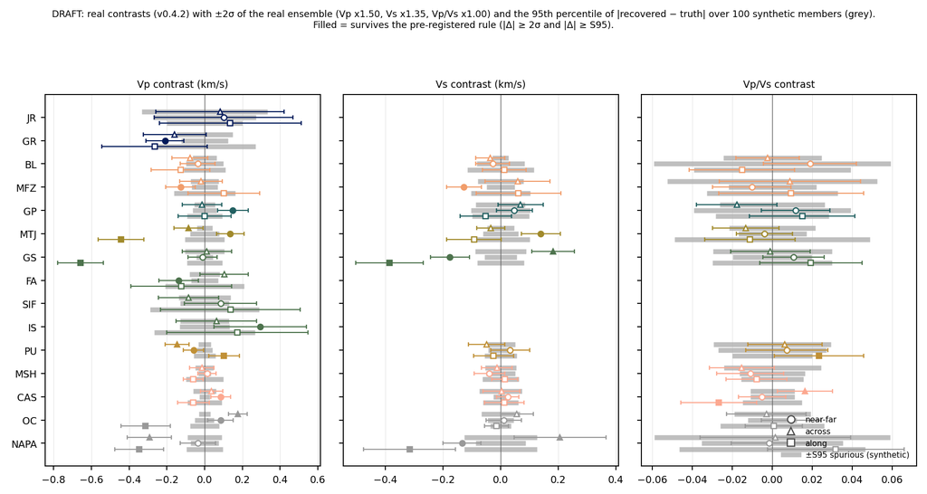

Real contrasts with ±2σ of the real ensemble and ±S95 of the synthetic spurious contrasts (grey). Filled = survives the pre-registered rule. Colours by segment type. Draft.

| seg | var | contrast | Δ real | σ ens | Δ truth (synth) | spurious mean | spurious sd | spurious p05 | spurious p95 | S95 = p95 \|spurious\| | recovery | noise floor sd | verdict |
| --- | --- | --- | --- | --- | --- | --- | --- | --- | --- | --- | --- | --- | --- |
| JR | Vp | across | +0.082 | 0.170 | +0.145 | -0.073 | 0.143 | -0.317 | +0.166 | 0.333 | 0.50 | 0.0001 | – |
| JR | Vp | along | +0.136 | 0.188 | +0.106 | +0.005 | 0.104 | -0.167 | +0.172 | 0.201 | 1.04 | 0.0000 | – |
| JR | Vp | near-far | +0.101 | 0.183 | -0.020 | +0.115 | 0.099 | -0.028 | +0.272 | 0.272 | -4.66 | 0.0000 | – |
| GR | Vp | across | -0.158 | 0.083 | -0.034 | +0.034 | 0.065 | -0.055 | +0.150 | 0.150 | -0.01 | 0.0008 | – |
| GR | Vp | along | -0.265 | 0.140 | +0.024 | -0.119 | 0.099 | -0.269 | +0.053 | 0.269 | -3.95 | 0.0007 | – |
| GR | Vp | near-far | -0.210 | 0.050 | -0.221 | +0.054 | 0.045 | -0.016 | +0.124 | 0.124 | 0.76 | 0.0009 | survives |
| BL | Vp | across | -0.078 | 0.047 | -0.025 | -0.011 | 0.030 | -0.061 | +0.038 | 0.064 | 1.44 | 0.0022 | – |
| BL | Vp | along | -0.127 | 0.078 | -0.319 | +0.042 | 0.048 | -0.036 | +0.109 | 0.109 | 0.87 | 0.0020 | – |
| BL | Vp | near-far | -0.037 | 0.046 | +0.004 | -0.047 | 0.030 | -0.098 | +0.006 | 0.098 | -11.84 | 0.0030 | – |
| BL | VpVs | across | -0.002 | 0.008 | +0.008 | -0.010 | 0.009 | -0.025 | +0.004 | 0.025 | -0.22 | 0.0019 | – |
| BL | VpVs | along | -0.015 | 0.013 | -0.056 | +0.016 | 0.015 | -0.008 | +0.039 | 0.039 | 0.72 | 0.0010 | – |
| BL | VpVs | near-far | +0.019 | 0.012 | +0.045 | -0.041 | 0.011 | -0.059 | -0.025 | 0.059 | 0.08 | 0.0013 | – |
| BL | Vs | across | -0.036 | 0.025 | -0.008 | -0.005 | 0.015 | -0.027 | +0.022 | 0.028 | 1.58 | 0.0018 | – |
| BL | Vs | along | +0.013 | 0.038 | +0.062 | -0.076 | 0.028 | -0.116 | -0.024 | 0.116 | -0.23 | 0.0021 | – |
| BL | Vs | near-far | -0.028 | 0.029 | -0.074 | +0.047 | 0.022 | +0.013 | +0.084 | 0.084 | 0.36 | 0.0031 | – |
| MFZ | Vp | across | -0.019 | 0.056 | -0.072 | -0.017 | 0.038 | -0.075 | +0.042 | 0.075 | 1.24 | 0.0003 | – |
| MFZ | Vp | along | +0.102 | 0.095 | +0.220 | -0.044 | 0.070 | -0.160 | +0.067 | 0.164 | 0.80 | 0.0002 | – |
| MFZ | Vp | near-far | -0.128 | 0.039 | -0.076 | +0.013 | 0.031 | -0.034 | +0.068 | 0.068 | 0.83 | 0.0002 | survives |
| MFZ | VpVs | across | +0.009 | 0.018 | +0.016 | -0.020 | 0.020 | -0.052 | +0.012 | 0.052 | -0.24 | 0.0001 | – |
| MFZ | VpVs | along | +0.009 | 0.018 | -0.019 | -0.005 | 0.017 | -0.030 | +0.022 | 0.033 | 1.27 | 0.0002 | – |
| MFZ | VpVs | near-far | -0.010 | 0.010 | +0.003 | +0.001 | 0.011 | -0.017 | +0.020 | 0.022 | 1.44 | 0.0001 | – |
| MFZ | Vs | across | +0.059 | 0.056 | +0.012 | +0.005 | 0.041 | -0.071 | +0.063 | 0.079 | 1.42 | 0.0001 | – |
| MFZ | Vs | along | +0.062 | 0.074 | -0.039 | +0.001 | 0.054 | -0.076 | +0.084 | 0.104 | 0.96 | 0.0002 | – |
| MFZ | Vs | near-far | -0.128 | 0.030 | -0.052 | +0.009 | 0.025 | -0.030 | +0.045 | 0.048 | 0.83 | 0.0001 | survives |
| GP | Vp | across | -0.013 | 0.052 | -0.158 | +0.004 | 0.027 | -0.041 | +0.046 | 0.055 | 0.98 | 0.0006 | – |
| GP | Vp | along | +0.001 | 0.070 | -0.110 | +0.028 | 0.044 | -0.043 | +0.088 | 0.093 | 0.75 | 0.0005 | – |
| GP | Vp | near-far | +0.149 | 0.040 | +0.171 | -0.020 | 0.026 | -0.061 | +0.019 | 0.064 | 0.88 | 0.0004 | survives |
| GP | VpVs | across | -0.018 | 0.010 | -0.042 | -0.001 | 0.014 | -0.023 | +0.017 | 0.026 | 1.03 | 0.0001 | – |
| GP | VpVs | along | +0.015 | 0.013 | +0.019 | -0.008 | 0.015 | -0.028 | +0.017 | 0.028 | 0.58 | 0.0004 | – |
| GP | VpVs | near-far | +0.012 | 0.009 | -0.006 | +0.023 | 0.010 | +0.006 | +0.039 | 0.039 | -3.05 | 0.0002 | – |

[output cut: 75 more lines]

## 4. Seismicity-style metrics

Mc: maximum curvature + 0.2 on the segment's tier A-C magnitudes (v6.1 M: converged magnitudes on the v6.1 hypocentres, D-B105); b: Aki-Utsu for continuous magnitudes above Mc; both re-estimated in 500 event bootstrap draws (95 % intervals). "Mc map": event-weighted median of the v6.1 Mc map cells (flagged events excluded). Clustering shares: v6.1 nearest-neighbour clustering, events in its analysis set (above the regional Mc of that run), with a bootstrap over units (one background event or one whole family).

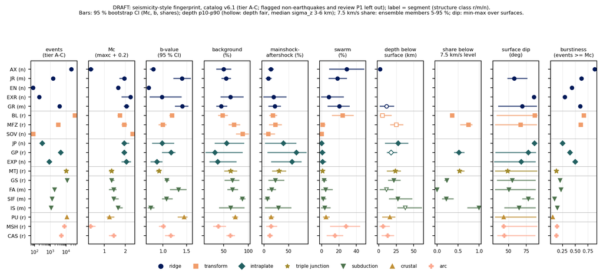

Seismicity-style fingerprint of the plate-boundary segments (mock-up of main figure 2). Label: segment code and structure class (r resolved, m marginal, n not resolved). Draft.

### Size, completeness, clustering

| seg | type | events | with M | Mmax | M≥4 | Mc | Mc lo | Mc hi | Mc map | b | b lo | b hi | n ≥ Mc | n clustering | bg % | bg lo | bg hi | MA % | swarm % | multiplet % | swarm % of clustered | MA fam | swarm fam | multiplet fam | swarm fam ≥10 | migrating (zbz) | DBSCAN swarm-like | migrating (DBSCAN) |
| --- | --- | --- | --- | --- | --- | --- | --- | --- | --- | --- | --- | --- | --- | --- | --- | --- | --- | --- | --- | --- | --- | --- | --- | --- | --- | --- | --- | --- |
| AX | ridge | 21,171 | 11,319 | 4.73 | 4 | 0.35 | 0.35 | 0.45 | 0.10 | 0.80 | 0.74 | 0.82 | 4,863 | 2,506 | 50 | 36 | 64 | 14 | 29 | 7 | 58 | 157 | 32 | 119 | 11 | 3 | 16 | 0 |
| JR | ridge | 1,492 | 883 | 3.50 | 0 | 1.95 | 1.75 | 1.95 | 1.70 | 1.41 | 1.23 | 1.58 | 201 | 360 | 55 | 46 | 64 | 9 | 18 | 18 | 40 | 12 | 12 | 37 | 1 | 0 | 3 | 0 |
| EN | ridge | 81 | 58 | 3.15 | 0 | 1.65 | – | – | 1.40 | 0.70 | – | – | 33 | 20 | – | – | – | – | – | – | – | 2 | 0 | 0 | 0 | 0 | 0 | 0 |
| EXR | ridge | 198 | 180 | 4.68 | 2 | 2.25 | 1.85 | 2.25 | 1.60 | 0.98 | 0.73 | 1.38 | 38 | 61 | 64 | 45 | 89 | 20 | 8 | 8 | 23 | 1 | 1 | 3 | 0 | 0 | 0 | 0 |
| GR | ridge | 3,860 | 2,777 | 5.53 | 5 | 2.05 | 1.95 | 2.15 | 1.90 | 1.41 | 1.27 | 1.53 | 722 | 537 | 45 | 36 | 56 | 22 | 20 | 13 | 37 | 19 | 10 | 30 | 4 | 2 | 18 | 0 |
| BL | transform | 36,523 | 29,460 | 5.95 | 33 | 1.75 | 1.65 | 1.75 | 1.50 | 1.19 | 1.15 | 1.22 | 8,579 | 8,571 | 48 | 40 | 57 | 18 | 25 | 10 | 47 | 283 | 98 | 349 | 28 | 3 | 160 | 9 |
| MFZ | transform | 3,253 | 2,499 | 6.60 | 12 | 1.95 | 1.85 | 2.05 | 1.80 | 1.00 | 0.92 | 1.07 | 906 | 802 | 72 | 61 | 82 | 23 | 1 | 4 | 4 | 38 | 1 | 18 | 0 | 0 | 2 | 0 |
| SOV | transform | 86 | 78 | 4.82 | 2 | 2.35 | – | – | 1.70 | – | – | – | 19 | 44 | 89 | 76 | 100 | 9 | 0 | 2 | 0 | 1 | 0 | 0 | 0 | 0 | 0 | 0 |
| JP | intraplate | 316 | 256 | 5.62 | 2 | 1.95 | 1.95 | 2.15 | 1.50 | 0.98 | 0.78 | 1.23 | 125 | 170 | 56 | 33 | 91 | 39 | 0 | 5 | 0 | 5 | 0 | 8 | 0 | 0 | 0 | 0 |
| GP | intraplate | 4,710 | 3,962 | 6.80 | 15 | 1.95 | 1.95 | 2.05 | 1.70 | 1.17 | 0.99 | 1.26 | 1,080 | 1,785 | 32 | 14 | 88 | 66 | 1 | 1 | 1 | 22 | 2 | 12 | 0 | 0 | 2 | 0 |
| EXP | intraplate | 873 | 818 | 6.53 | 12 | 2.05 | 1.85 | 2.25 | 1.80 | 0.88 | 0.75 | 0.98 | 382 | 391 | 38 | 22 | 75 | 57 | 1 | 3 | 2 | 17 | 1 | 5 | 0 | 0 | 0 | 0 |
| MTJ | triple junction | 10,474 | 8,996 | 5.88 | 21 | 1.35 | 1.25 | 1.40 | 1.10 | 0.92 | 0.87 | 0.95 | 4,268 | 2,313 | 64 | 52 | 76 | 31 | 1 | 4 | 3 | 110 | 4 | 44 | 0 | 0 | 3 | 0 |
| GS | subduction | 11,946 | 9,351 | 6.50 | 11 | 1.35 | 1.35 | 1.45 | 1.10 | 1.09 | 1.05 | 1.12 | 3,690 | 1,663 | 68 | 53 | 81 | 23 | 3 | 6 | 9 | 55 | 6 | 43 | 2 | 0 | 23 | 1 |
| FA | subduction | 1,882 | 1,547 | 6.41 | 1 | 1.45 | 1.25 | 1.55 | 1.20 | 1.33 | 1.16 | 1.49 | 448 | 171 | 68 | 59 | 78 | 16 | 5 | 11 | 15 | 11 | 1 | 8 | 0 | 0 | 2 | 0 |
| SIF | subduction | 1,307 | 1,174 | 4.00 | 0 | 1.45 | 1.45 | 1.65 | 1.20 | 1.08 | 0.99 | 1.19 | 514 | 384 | 89 | 84 | 93 | 7 | 2 | 3 | 16 | 9 | 1 | 4 | 0 | 0 | 0 | 0 |
| IS | subduction | 1,150 | 1,036 | 5.51 | 6 | 1.65 | 1.65 | 1.85 | 1.30 | 0.74 | 0.69 | 0.81 | 519 | 486 | 65 | 42 | 92 | 30 | 3 | 2 | 10 | 13 | 2 | 6 | 1 | 0 | 0 | 0 |
| PU | crustal | 11,348 | 10,949 | 3.94 | 0 | 1.25 | 1.15 | 1.45 | 1.10 | 1.45 | 1.32 | 1.51 | 3,901 | 2,805 | 74 | 69 | 78 | 15 | 5 | 7 | 20 | 118 | 12 | 83 | 5 | 0 | 8 | 0 |
| MSH | arc | 7,799 | 7,658 | 3.95 | 0 | 0.35 | 0.35 | 0.55 | 0.20 | 1.01 | 0.93 | 1.05 | 3,304 | 243 | 39 | 30 | 54 | 14 | 28 | 18 | 47 | 19 | 11 | 43 | 6 | 2 | 44 | 0 |
| CAS | arc | 5,045 | 4,957 | 4.10 | 1 | 1.45 | 1.25 | 1.55 | 0.80 | 1.17 | 1.06 | 1.24 | 1,139 | 1,017 | 64 | 57 | 72 | 12 | 15 | 9 | 43 | 38 | 11 | 37 | 9 | 0 | 8 | 0 |
| OC | other | 7,498 | 7,215 | 4.07 | 2 | 1.05 | 1.05 | 1.25 | 1.00 | 1.11 | 1.08 | 1.29 | 3,311 | 701 | 82 | 76 | 87 | 11 | 1 | 7 | 5 | 23 | 1 | 27 | 0 | 0 | 3 | 0 |
| NAPA | other | 4,305 | 3,534 | 5.69 | 6 | 1.35 | 1.25 | 1.45 | 1.10 | 0.88 | 0.83 | 0.93 | 1,628 | 918 | 75 | 70 | 81 | 15 | 2 | 8 | 9 | 50 | 3 | 37 | 0 | 0 | 2 | 0 |

### Depth and geometry

bsf = depth below the solid surface (ground or seafloor), depth-good events only (tier A-C, depth_quality ok, not floor-limited, far-only or deep-pass). For segments without depth-good events the raw median is given in the "unconstrained" column and should not be used. 7.5 and 8 km/s levels: depth of the first Vp crossing in the event's model column between two P-resolved nodes; "members p05/p95" = the share recomputed with each member's level (raw spread). Fault-surface columns: v1 surfaces of the segment (dip weighted by member count; seismogenic width = 2-98 % depth range of depth-ok members).

| seg | depth class | depth-good | median σz | bsf p10 | bsf p50 | p50 lo | p50 hi | bsf p90 | p90 lo | p90 hi | bsf p50 (unconstrained) | 7.5 km/s level bsf | share with level | below 7.5 | lo | hi | members p05 | members p95 | share with 8 km/s | below 8 | depth - Slab2 | dip (wtd) | dip min | dip max | seismogenic width | seismogenic bottom | share on surfaces |
| --- | --- | --- | --- | --- | --- | --- | --- | --- | --- | --- | --- | --- | --- | --- | --- | --- | --- | --- | --- | --- | --- | --- | --- | --- | --- | --- | --- |
| AX | good | 20,387 | 0.81 | 0.98 | 1.84 | 1.84 | 1.85 | 2.51 | 2.47 | 2.54 | – | – | 0.00 | – | – | – | – | – | 0.00 | – | – | – | – | – | – | – | – |
| JR | none | 0 | – | – | – | – | – | – | – | – | 0.37 | – | – | – | – | – | – | – | – | – | – | 58.07 | 49.10 | 75.80 | – | – | 0.12 |
| EN | none | 0 | – | – | – | – | – | – | – | – | 1.28 | – | – | – | – | – | – | – | – | – | – | – | – | – | – | – | – |
| EXR | none | 0 | – | – | – | – | – | – | – | – | 41.16 | – | – | – | – | – | – | – | – | – | – | 85.90 | 85.90 | 85.90 | – | – | 0.11 |
| GR | fair | 1,373 | 4.56 | 2.27 | 10.93 | 10.55 | 11.23 | 21.06 | 19.59 | 22.18 | – | – | 0.00 | – | – | – | – | – | 0.00 | – | – | 69.19 | 36.00 | 89.40 | 17.40 | 30.20 | 0.71 |
| BL | fair | 18,796 | 4.78 | 2.26 | 5.47 | 5.40 | 5.53 | 17.62 | 17.36 | 17.82 | – | 8.45 | 0.95 | 0.36 | 0.35 | 0.36 | 0.32 | 0.37 | 0.36 | 0.18 | – | 86.88 | 34.10 | 89.90 | 23.90 | 29.00 | 0.68 |
| MFZ | fair | 2,515 | 4.54 | 17.45 | 25.23 | 24.94 | 25.67 | 34.45 | 33.91 | 34.93 | – | 21.26 | 0.81 | 0.75 | 0.73 | 0.77 | 0.57 | 0.83 | 0.00 | – | – | 67.00 | 31.90 | 89.20 | 12.00 | 33.20 | 0.57 |
| SOV | none | 0 | – | – | – | – | – | – | – | – | 45.30 | – | – | – | – | – | – | – | – | – | – | – | – | – | – | – | – |
| JP | poor | 194 | 6.50 | 9.58 | 27.99 | 26.19 | 30.43 | 41.65 | 38.58 | 50.94 | – | – | 0.00 | – | – | – | – | – | 0.00 | – | – | 86.50 | 86.50 | 86.50 | 19.40 | 41.30 | 0.15 |
| GP | fair | 356 | 3.80 | 12.59 | 17.79 | 17.11 | 18.40 | 25.43 | 23.56 | 27.12 | – | 19.88 | 0.31 | 0.52 | 0.43 | 0.63 | 0.42 | 0.64 | 0.33 | 0.29 | – | 77.80 | 32.20 | 87.80 | – | – | 0.35 |
| EXP | none | 0 | – | – | – | – | – | – | – | – | 41.70 | – | – | – | – | – | – | – | – | – | – | 67.96 | 30.70 | 87.50 | – | – | 0.41 |
| MTJ | good | 10,335 | 1.82 | 12.19 | 23.97 | 23.82 | 24.11 | 30.84 | 30.76 | 30.94 | – | 21.96 | 0.97 | 0.54 | 0.53 | 0.55 | 0.52 | 0.63 | 0.50 | 0.64 | 10.95 | 48.95 | 31.80 | 89.50 | 17.10 | 29.15 | 0.72 |
| GS | good | 11,831 | 2.06 | 14.16 | 21.76 | 21.63 | 21.86 | 30.52 | 30.35 | 30.67 | – | 25.54 | 0.92 | 0.23 | 0.23 | 0.24 | 0.19 | 0.25 | 0.16 | 0.20 | 2.96 | 55.12 | 34.50 | 87.50 | 13.10 | 32.30 | 0.10 |
| FA | fair | 1,776 | 3.42 | 2.07 | 10.91 | 10.51 | 11.18 | 20.46 | 19.50 | 21.33 | – | 27.42 | 0.04 | 0.00 | 0.00 | 0.00 | 0.00 | 0.00 | 0.01 | – | -13.86 | 50.69 | 31.90 | 87.40 | 11.25 | 19.00 | 0.32 |
| SIF | good | 1,303 | 2.10 | 15.49 | 27.17 | 26.72 | 27.89 | 47.40 | 45.70 | 48.45 | – | 26.79 | 0.05 | 0.22 | 0.13 | 0.32 | 0.13 | 0.38 | 0.00 | – | 0.25 | 77.80 | 70.20 | 85.40 | 14.30 | 29.95 | 0.03 |
| IS | fair | 1,130 | 3.43 | 27.26 | 37.75 | 36.83 | 38.76 | 60.95 | 59.76 | 62.67 | – | 55.11 | 0.05 | 1.00 | 1.00 | 1.00 | 0.73 | 1.00 | 0.00 | – | 12.45 | 64.65 | 45.00 | 87.40 | 10.90 | 37.20 | 0.18 |
| PU | good | 10,941 | 2.52 | 5.73 | 15.71 | 15.60 | 15.80 | 23.14 | 22.93 | 23.41 | – | – | 0.00 | – | – | – | – | – | 0.00 | – | -33.72 | 43.04 | 31.60 | 88.40 | 14.35 | 24.85 | 0.41 |
| MSH | good | 7,568 | 1.07 | 2.00 | 6.12 | 6.10 | 6.29 | 15.17 | 15.10 | 15.26 | – | – | 0.00 | – | – | – | – | – | 0.00 | – | -55.64 | 43.27 | 42.70 | 89.70 | 14.70 | 28.30 | 0.59 |
| CAS | good | 4,906 | 2.55 | 4.74 | 12.87 | 12.72 | 13.03 | 21.34 | 21.14 | 21.61 | – | – | 0.00 | – | – | – | – | – | 0.00 | – | -59.88 | 44.08 | 35.00 | 87.20 | 10.80 | 16.40 | 0.38 |
| OC | good | 7,064 | 2.43 | 5.01 | 14.99 | 14.81 | 15.14 | 22.42 | 22.14 | 22.65 | – | 28.57 | 0.03 | 0.00 | 0.00 | 0.00 | 0.00 | 0.00 | 0.00 | 0.00 | -32.69 | 54.63 | 30.80 | 87.70 | 11.10 | 20.20 | 0.28 |
| NAPA | good | 4,167 | 2.08 | 6.35 | 23.23 | 22.89 | 23.45 | 32.33 | 32.20 | 32.47 | – | 32.45 | 0.29 | 0.27 | 0.25 | 0.30 | 0.17 | 0.54 | 0.00 | – | -0.35 | 54.69 | 31.80 | 76.50 | 14.60 | 22.25 | 0.64 |

### Temporal character

Events ≥ the segment Mc over the whole period. COV = coefficient of variation of inter-event times (1 for a Poisson process); burstiness = (σ − μ)/(σ + μ). The network changed with the OBS deployments (2011-2015) and Axial enters tier A-C only from 2013-09, so rates and burstiness compare segments only roughly.

| seg | first | last | years | events ≥ Mc per yr | COV all | burstiness all | COV bg | burstiness bg | share on busiest 1 % of days | largest family / events |
| --- | --- | --- | --- | --- | --- | --- | --- | --- | --- | --- |
| AX | 2013-09-05 | 2016-12-31 | 4 | 1596 | 15.98 | 0.88 | 12.80 | 0.86 | 0.29 | 0.03 |
| JR | 2010-08-01 | 2016-05-07 | 7 | 35 | 4.27 | 0.62 | 2.87 | 0.48 | 0.38 | 0.08 |
| EN | 2011-12-03 | 2016-08-06 | 6 | 7 | 2.54 | 0.44 | 1.94 | 0.32 | 0.76 | 0.22 |
| EXR | 2010-01-12 | 2016-12-09 | 7 | 6 | 1.83 | 0.29 | 1.38 | 0.16 | 0.74 | 0.05 |
| GR | 2010-08-15 | 2015-11-12 | 6 | 142 | 4.01 | 0.60 | 3.08 | 0.51 | 0.30 | 0.05 |
| BL | 2010-01-09 | 2016-12-23 | 7 | 1234 | 5.08 | 0.67 | 3.63 | 0.57 | 0.20 | 0.04 |
| MFZ | 2010-01-03 | 2016-12-08 | 7 | 131 | 4.14 | 0.61 | 1.48 | 0.19 | 0.15 | 0.14 |
| SOV | 2010-07-29 | 2016-09-23 | 5 | 6 | – | – | – | – | 0.63 | 0.05 |
| JP | 2010-02-24 | 2016-09-11 | 7 | 19 | 1.67 | 0.25 | 1.50 | 0.20 | 0.33 | 0.26 |
| GP | 2010-01-06 | 2016-12-06 | 7 | 156 | 2.34 | 0.40 | 1.83 | 0.29 | 0.38 | 0.54 |
| EXP | 2010-03-25 | 2016-06-09 | 7 | 62 | 3.01 | 0.50 | 1.77 | 0.28 | 0.50 | 0.31 |
| MTJ | 2010-01-01 | 2016-01-10 | 7 | 709 | 1.30 | 0.13 | 1.42 | 0.17 | 0.09 | 0.07 |
| GS | 2010-01-02 | 2016-04-24 | 7 | 585 | 1.52 | 0.21 | 1.34 | 0.14 | 0.08 | 0.15 |
| FA | 2010-01-05 | 2016-12-05 | 7 | 65 | 1.56 | 0.22 | 1.44 | 0.18 | 0.18 | 0.02 |
| SIF | 2010-01-07 | 2016-12-09 | 7 | 74 | 1.21 | 0.10 | 1.17 | 0.08 | 0.13 | 0.01 |
| IS | 2010-01-02 | 2016-12-25 | 7 | 75 | 1.35 | 0.15 | 1.03 | 0.01 | 0.25 | 0.29 |
| PU | 2010-01-01 | 2016-12-31 | 7 | 557 | 1.12 | 0.06 | 1.05 | 0.02 | 0.05 | 0.02 |
| MSH | 2010-01-01 | 2016-12-30 | 7 | 472 | 1.33 | 0.14 | 1.18 | 0.08 | 0.12 | 0.05 |
| CAS | 2010-01-01 | 2016-12-28 | 7 | 163 | 1.30 | 0.13 | 1.12 | 0.06 | 0.12 | 0.01 |
| OC | 2010-01-02 | 2016-12-29 | 7 | 474 | 1.17 | 0.08 | 1.13 | 0.06 | 0.06 | 0.01 |
| NAPA | 2010-01-02 | 2016-03-09 | 7 | 264 | 1.65 | 0.24 | 1.49 | 0.20 | 0.09 | 0.01 |

### Mount St Helens swarm share, v6.0 to v6.1, family by family

| family_old | Mmax | n_segment_analysis | families_new | types_new | tier D | v61 swarm | v61 multiplet | analog_test_signal flag | v61 mainshock-aftershock | v61 background | not located | below Mc |
| --- | --- | --- | --- | --- | --- | --- | --- | --- | --- | --- | --- | --- |
| 837 | 3.52 | 28 | 808 | swarm | 0.00 | 27.00 | 0.00 | 0.00 | 0.00 | 0.00 | 0.00 | 1.00 |
| 109 | 1.99 | 11 | 107;108 | multiplet;swarm | 2.00 | 7.00 | 1.00 | 1.00 | 0.00 | 0.00 | 0.00 | 0.00 |
| 144 | 3.96 | 11 | 142 | mainshock-aftershock | 0.00 | 0.00 | 0.00 | 0.00 | 11.00 | 0.00 | 0.00 | 0.00 |
| 128 | 2.51 | 10 | 124;125 | swarm;swarm | 3.00 | 7.00 | 0.00 | 0.00 | 0.00 | 0.00 | 0.00 | 0.00 |
| 143 | 2.87 | 8 | 137;140 | swarm;swarm | 1.00 | 7.00 | 0.00 | 0.00 | 0.00 | 0.00 | 0.00 | 0.00 |
| 145 | 2.80 | 7 | 135;141;162 | swarm;swarm;multiplet | 2.00 | 4.00 | 1.00 | 0.00 | 0.00 | 0.00 | 0.00 | 0.00 |
| 1,987 | 2.75 | 6 | 2011;2021 | mainshock-aftershock;multiplet | 1.00 | 0.00 | 2.00 | 0.00 | 0.00 | 3.00 | 0.00 | 0.00 |
| 1,434 | 3.04 | 4 | 1439 | multiplet | 0.00 | 0.00 | 3.00 | 0.00 | 0.00 | 1.00 | 0.00 | 0.00 |
| 138 | 2.79 | 4 | 135 | swarm | 1.00 | 3.00 | 0.00 | 0.00 | 0.00 | 0.00 | 0.00 | 0.00 |
| 181 | 3.22 | 4 | 175 | swarm | 0.00 | 3.00 | 0.00 | 0.00 | 0.00 | 1.00 | 0.00 | 0.00 |
| 917 | 3.10 | 3 | 884;885;887 | multiplet;mainshock-aftershock;multiplet | 2.00 | 0.00 | 1.00 | 0.00 | 0.00 | 0.00 | 0.00 | 0.00 |
| 364 | 2.68 | 3 | 349 | swarm | 0.00 | 2.00 | 0.00 | 0.00 | 0.00 | 0.00 | 1.00 | 0.00 |
| 1,958 | 2.78 | 2 | 1994 | multiplet | 0.00 | 0.00 | 2.00 | 0.00 | 0.00 | 0.00 | 0.00 | 0.00 |
| 526 | 3.06 | 2 | 509 | multiplet | 0.00 | 0.00 | 1.00 | 0.00 | 0.00 | 0.00 | 1.00 | 0.00 |
| 30 | 1.83 | 1 | 26 | mainshock-aftershock | 1.00 | 0.00 | 0.00 | 0.00 | 0.00 | 0.00 | 0.00 | 0.00 |
| 235 | 3.15 | 1 | – | – | 0.00 | 0.00 | 0.00 | 1.00 | 0.00 | 0.00 | 0.00 | 0.00 |
| 260 | 3.17 | 1 | – | – | 0.00 | 0.00 | 0.00 | 1.00 | 0.00 | 0.00 | 0.00 | 0.00 |
| 411 | 3.19 | 1 | – | – | 0.00 | 0.00 | 0.00 | 1.00 | 0.00 | 0.00 | 0.00 | 0.00 |

## 5. Figure plan

Six main figures, each a set of small multiples with segments on a shared axis and one colour or marker per boundary type (ridge, transform, intraplate, triple junction, subduction, crustal, arc). Velocity appears only in figures 4 and 5 and only on resolved nodes near the segments. All on catalog v6.1 and model v0.4.2.

[output not shown]

**Supplement.** S1 segment rule and threshold sensitivity (sec. 7); S2 Mc maps, three methods and by period (current fig2a, fig2b, on v6.1 without flagged events, D-B105); S3 catalog comparison (current figS); S4 nearest-neighbour density plots by segment type (current fig5 A-C, regrouped); S5 structure feasibility: node counts, checkerboard share and ensemble 1σ maps limited to the segment areas; S6 five individual ensemble members of the BL and MFZ sections (what the 1σ means); S7 Mendocino perspective view (current perspective_mendocino_fault); S8 migrating swarms (AX 3 zbz + 0 DBSCAN, GR 2 zbz + 0 DBSCAN, BL 3 zbz + 9 DBSCAN, GS 0 zbz + 1 DBSCAN, MSH 2 zbz + 0 DBSCAN); S9 the unresolved boundaries (Axial, Endeavour, Explorer, JdF plate): seismicity-only panels.

**Leaves the main text:** fig2a and fig2b (Mc maps) move to the supplement; fig5 A-C move to S4; fig4 becomes a panel of figure 3 or moves to the supplement. No full-size velocity maps or margin-normal model sections (D-B107).

## 6. Mock-up: fault-normal sections, Blanco and Mendocino fault zone

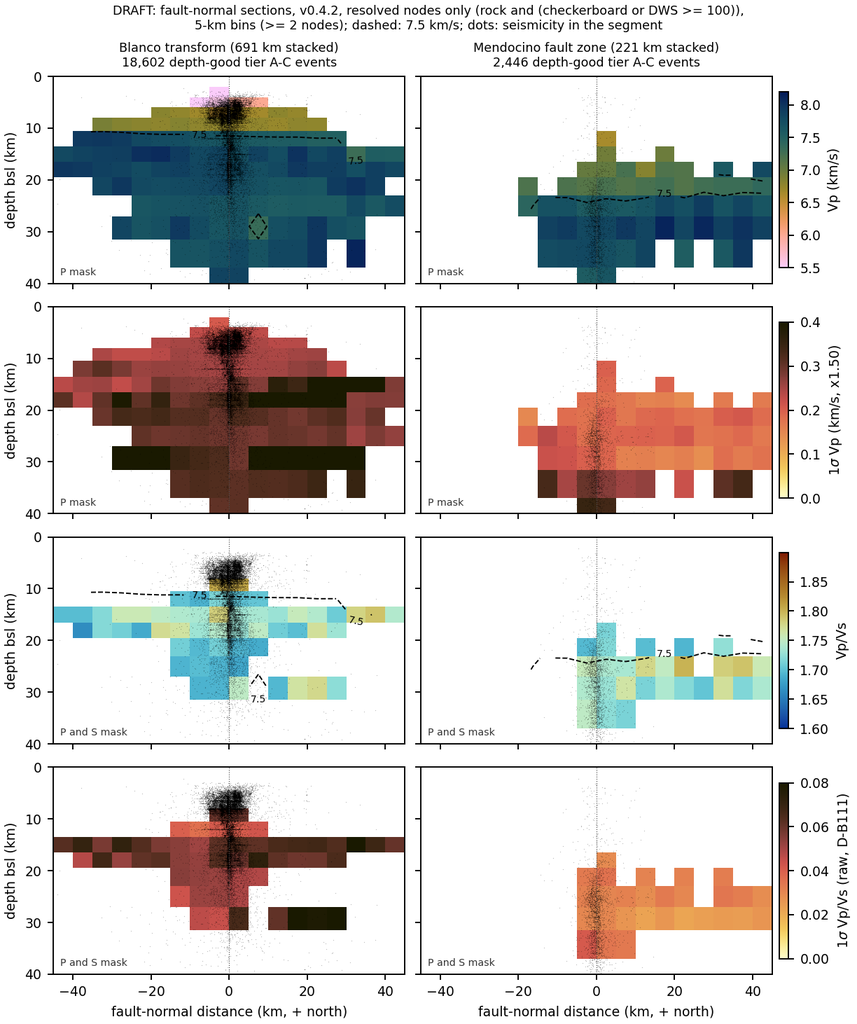

Model v0.4.2 on resolved nodes in 5 km bins of fault-normal distance (≥ 2 nodes per bin), stacked along 691 km (Blanco) and 221 km (MFZ) of the PB2002 transform trace and centred on the seismicity (trace offset +0.3 km and -0.0 km). Rows: Vp, its 1σ (x1.50), Vp/Vs (P and S mask), its 1σ (raw, D-B111). Dots: depth-good tier A-C events of the segment. Dashed: 7.5 km/s. Draft.

What the mock-up shows: within 10 km of the Blanco faults and seismicity the resolved layers span 3-40 km for Vp and 9-29 km for Vp/Vs and the seismicity sits in them; at MFZ 15-40 km (P) and 21-34 km (P and S), with 75% of the seismicity below the 7.5 km/s level. Median Vp 1σ: Blanco 0.28 km/s, MFZ 0.20 km/s. Structure within ±10 km of the faults is near the node spacing.

### Depth extent against the velocity level, per model column

| seg | level | n_columns | median D90 − level (km) | Spearman ρ | sd(D90 − level) | null sd (median) | p | sd D90 | sd level |
| --- | --- | --- | --- | --- | --- | --- | --- | --- | --- |
| BL | z75 | 55 | 8.36 | 0.12 | 6.19 | 6.61 | 0.010 | 6.53 | 1.34 |
| BL | z8 | 27 | 1.54 | 0.02 | 9.12 | 10.43 | 0.111 | 6.50 | 8.42 |
| GS | z75 | 67 | 2.56 | 0.53 | 3.62 | 5.42 | 0.001 | 4.50 | 3.07 |
| GS | z8 | 15 | 2.80 | -0.57 | 4.97 | 4.06 | 0.967 | 3.15 | 2.78 |
| MFZ | z75 | 17 | 12.82 | 0.15 | 2.90 | 3.06 | 0.282 | 2.95 | 1.10 |
| MTJ | z75 | 28 | 9.48 | 0.05 | 3.91 | 3.62 | 0.829 | 3.03 | 2.09 |
| MTJ | z8 | 18 | 5.89 | 0.54 | 2.41 | 3.37 | 0.006 | 2.95 | 1.86 |
| NAPA | z75 | 10 | 3.64 | 0.27 | 1.94 | 4.42 | 0.027 | 3.17 | 3.20 |

Columns with ≥ 20 depth-good events and a resolved level. p = share of 1000 permutations of the level among the segment's columns with a smaller sd(D90 − level).

### Swarm against mainshock-aftershock families on resolved nodes

| seg | var | n_swarm | n_MA | n_multiplet | swarm − MA (median) | null 2.5 % | null 97.5 % | p | σ members |
| --- | --- | --- | --- | --- | --- | --- | --- | --- | --- |
| BL | VpVs | 7 | 27 | 17 | -0.062 | -0.108 | +0.068 | 0.24 | 0.038 |
| BL | Vp | 26 | 63 | 48 | -0.001 | -0.037 | +0.053 | 1.00 | 0.085 |
| CAS | VpVs | 0 | 4 | 1 | – | – | – | – | – |
| CAS | Vp | 5 | 8 | 3 | -0.079 | -0.079 | -0.051 | 0.44 | 0.299 |
| FA | Vp | 1 | 5 | 1 | – | – | – | – | – |
| GR | Vp | 4 | 2 | 2 | – | – | – | – | – |
| GS | VpVs | 3 | 23 | 9 | – | – | – | – | – |
| GS | Vp | 4 | 27 | 11 | – | – | – | – | – |
| IS | Vp | 2 | 1 | 0 | – | – | – | – | – |
| MFZ | VpVs | 0 | 8 | 0 | – | – | – | – | – |
| MFZ | Vp | 1 | 11 | 0 | – | – | – | – | – |
| MSH | VpVs | 9 | 4 | 6 | – | – | – | – | – |
| MSH | Vp | 9 | 4 | 6 | – | – | – | – | – |
| MTJ | VpVs | 2 | 35 | 2 | – | – | – | – | – |
| MTJ | Vp | 4 | 39 | 2 | – | – | – | – | – |
| NAPA | VpVs | 0 | 6 | 3 | – | – | – | – | – |
| NAPA | Vp | 1 | 7 | 3 | – | – | – | – | – |
| OC | VpVs | 0 | 5 | 2 | – | – | – | – | – |
| OC | Vp | 0 | 10 | 3 | – | – | – | – | – |
| PU | VpVs | 7 | 14 | 8 | +0.005 | -0.042 | +0.032 | 0.66 | 0.017 |
| PU | Vp | 12 | 34 | 13 | +0.084 | -0.115 | +0.089 | 0.12 | 0.066 |
| SIF | Vp | 1 | 1 | 1 | – | – | – | – | – |

Families with ≥ 5 depth-good members, placed at the node nearest their median position. Null: type labels permuted among families of the same depth layer (2000 draws). σ members: the same difference in each member x calibration factor.

## 7. Caveats

### Threshold sensitivity (tier A-C events per segment)

| seg | default | R_MTJ_KM=30.0 | R_MTJ_KM=50.0 | D_AXIS_KM=10.0 | D_AXIS_KM=20.0 | LAT_GS=41.0 | LAT_GS=42.0 | SLAB_IF_KM=3.0 | SLAB_IF_KM=8.0 |
| --- | --- | --- | --- | --- | --- | --- | --- | --- | --- |
| AX | 21,171 | 21,171 | 21,171 | 21,171 | 21,171 | 21,171 | 21,171 | 21,171 | 21,171 |
| JR | 1,492 | 1,492 | 1,492 | 1,396 | 1,520 | 1,492 | 1,492 | 1,492 | 1,492 |
| EN | 81 | 81 | 81 | 81 | 81 | 81 | 81 | 81 | 81 |
| EXR | 198 | 198 | 198 | 112 | 278 | 198 | 198 | 198 | 198 |
| GR | 3,860 | 3,860 | 3,860 | 3,975 | 3,801 | 3,860 | 3,860 | 3,860 | 3,860 |
| BL | 36,523 | 36,523 | 36,523 | 36,523 | 36,523 | 36,523 | 36,523 | 36,523 | 36,523 |
| MFZ | 3,253 | 3,405 | 3,140 | 2,888 | 3,686 | 3,253 | 3,253 | 3,253 | 3,253 |
| SOV | 86 | 86 | 86 | 70 | 197 | 86 | 86 | 86 | 86 |
| JP | 316 | 316 | 316 | 407 | 288 | 316 | 316 | 316 | 316 |
| GP | 4,710 | 4,829 | 4,627 | 4,955 | 4,337 | 4,710 | 4,710 | 4,710 | 4,710 |
| EXP | 873 | 873 | 873 | 980 | 682 | 873 | 873 | 873 | 873 |
| MTJ | 10,474 | 6,703 | 14,010 | 10,474 | 10,474 | 10,474 | 10,474 | 10,474 | 10,474 |
| GS | 11,946 | 14,189 | 9,183 | 11,946 | 11,946 | 11,212 | 12,077 | 11,946 | 11,946 |
| FA | 1,882 | 1,882 | 1,882 | 1,882 | 1,882 | 1,966 | 1,809 | 2,079 | 1,642 |
| SIF | 1,307 | 1,307 | 1,307 | 1,307 | 1,307 | 1,669 | 1,288 | 831 | 1,823 |
| IS | 1,150 | 1,150 | 1,150 | 1,150 | 1,150 | 1,438 | 1,111 | 1,429 | 874 |
| PU | 11,348 | 11,348 | 11,348 | 11,348 | 11,348 | 11,348 | 11,348 | 11,348 | 11,348 |
| MSH | 7,799 | 7,799 | 7,799 | 7,799 | 7,799 | 7,799 | 7,799 | 7,799 | 7,799 |
| CAS | 5,045 | 5,045 | 5,045 | 5,045 | 5,045 | 5,045 | 5,045 | 5,045 | 5,045 |
| OC | 7,498 | 7,498 | 7,498 | 7,498 | 7,498 | 7,498 | 7,498 | 7,498 | 7,498 |
| NAPA | 4,305 | 5,562 | 3,728 | 4,310 | 4,304 | 4,305 | 4,305 | 4,305 | 4,305 |

## 8. Reproduce

Worktree /home/mdenolle/wt_pbplan, branch analysis/plate-boundaries (from origin/main 5b42fcd2; merged with pipeline/end-to-end f21e87c6, which added the PB_* variables). Catalog v6.1: `/wd1/mdenolle_data/catalog_v6/v6.1/cascadia_catalog_v6.1.csv`; tables `/wd1/mdenolle_data/paper_plan/v6.1/tables`; page and figures `/wd1/mdenolle_data/paper_plan/v6.1`; run with workflow/11_paper_plan/run_v61.sh. Python:

```
LD_LIBRARY_PATH=/home/mdenolle/cascadia_obs_ensemble/.pixi/envs/default/lib
/home/mdenolle/cascadia_obs_ensemble/.pixi/envs/default/bin/python
```

, nice 10, one process. In `workflow/11_paper_plan/`: `pb_structure.py` (events with segments, levels, feasibility, contrasts; about 40 s), `pb_seismicity.py`, `pb_struct_seis.py`, `pb_sensitivity.py`, `pb_figures.py`, `pb_circularity.py` (after pb_structure.py, which writes the contrast node sets), `pb_page.py "$(date)"`. Small tables: `data/paper_plan/plate_boundaries/`; page, figures and the event table: /wd1/mdenolle_data/paper_plan/. Colour helpers: `workflow/08_figures/scm_palettes.py` (copy of paper/model-figures 7aea31dd).

- catalog v6.1: `/wd1/mdenolle_data/catalog_v6/v6.1/cascadia_catalog_v6.1.csv` (md5 1cd909b59cb8493bc823ad60a07fbcde)
- clustering events: `/wd1/mdenolle_data/catalog_v6/v6.1_analysis/clusters/events_zbz_v61.csv.gz` (md5 cb071b1d9f44afebdea9236829befe84)
- clustering families: `/wd1/mdenolle_data/catalog_v6/v6.1_analysis/clusters/families_zbz_v61.csv` (md5 63834d48877603628f5d571ef2709b7b)
- Mc map v6.1: `/wd1/mdenolle_data/magnitude_converged/mc_maps_v61/mc_grid.csv` (md5 adb9e89960b82e9adc15b42b70fa0925)
- model v0.4.2: `/wd1/mdenolle_data/tomo_v1/models/cascadia_obs_tomo/v0.4.2.nc` (md5 6cd65a101c12e827b00b7c13b0e32e2f)
- ensemble v0.4.2+ens.100: `/wd1/mdenolle_data/tomo_v1/models/cascadia_obs_tomo/v0.4.2+ens.100.nc` (md5 0408277b95ae133820afe74f00b99d76)
- fault surfaces v1 mesh: `/wd1/mdenolle_data/catalog_v6/v6.1_analysis/faults/fault_surfaces_v1_vertices.csv.gz` (md5 6eaf38343b33626908214523c0d65d9e)
- fault surfaces v1 summary: `/wd1/mdenolle_data/catalog_v6/v6.1_analysis/faults/fault_surfaces_v1_summary.csv` (md5 a88f3623083a0afd2a02d90354621b1f)